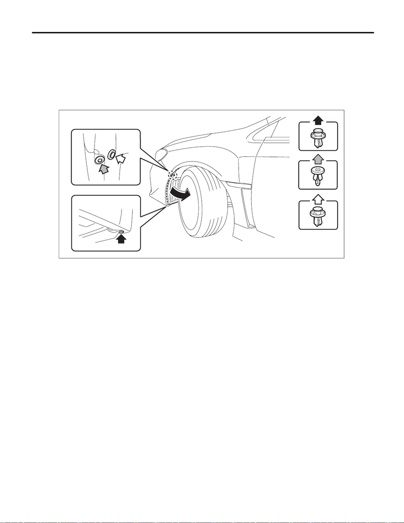

LI-38

Front Turn Signal Light Bulb

LIGHTING SYSTEM

19.Front Turn Signal Light Bulb

A: REMOVAL

1) Disconnect the ground cable from battery. <Ref. to NT-5, BATTERY, NOTE, Note.>

NOTE:

For models other than STI model, disconnect the ground terminal from battery sensor.

2) Turn the steering wheel in the opposite direction from the parts to be removed. Then remove the clips and

turn over the mud guard - front.

3) Disconnect the connector and remove the front turn signal light bulb. <Ref. to LI-37, DISASSEMBLY,

Front Turn Signal Light Assembly.>

B: INSTALLATION

1) Install the front turn signal light bulb. <Ref. to LI-37, ASSEMBLY, Front Turn Signal Light Assembly.>

2) Install the mud guard - front.

3) Connect the battery ground terminal. <Ref. to NT-5, BATTERY, NOTE, Note.>

NOTE:

For models other than STI model, connect the ground terminal to battery sensor.

LI-01717